# Metabolite–Gene Associations

```r
cat("\nSaved", nrow(top20), "global-FDR scatters to", scatter_dir, "\n")
```

Saved 20 global-FDR scatters to /scratch/jdlab/sneha/developing-brain-metabolomics/results/gene-metabolite/csv-log2_na/scatter-plots

## Total associations by cell type

```r
p_assoc <- ggplot(ct_recur,
                  aes(x = reorder(cell_type, n_associations), y = n_associations)) +
  geom_col(fill = "#4E79A7", alpha = 0.85) +
  coord_flip() +
  labs(x = NULL, y = "Total associations",
       title = "Gene\u2013metabolite associations by cell type") +
  theme_cowplot(12)

save_dual_format(p_assoc, out_dir, "associations_by_celltype", width = 8, height = 6)
```

```
## Saved: associations_by_celltype.png  +  svg/associations_by_celltype.svg
```

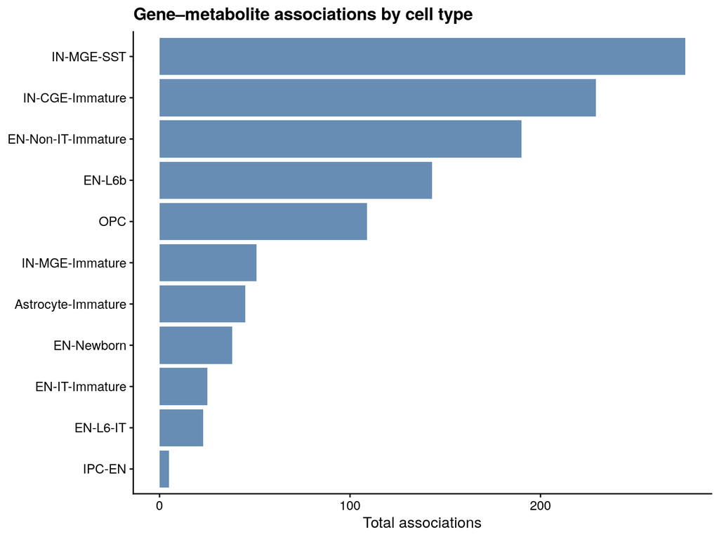

```r
print(p_assoc)
```

## Distinct metabolites by cell type

```r
p_ct_metab <- ggplot(ct_recur,
                     aes(x = reorder(cell_type, n_metabolites), y = n_metabolites)) +
  geom_col(fill = "#F28E2B", alpha = 0.85) +
  coord_flip() +
  labs(x = NULL, y = "Distinct metabolites",
       title = "Distinct metabolites associated per cell type") +
  theme_cowplot(12)

save_dual_format(p_ct_metab, out_dir, "distinct_metabolites_by_celltype", width = 8, height = 6)
```

```
## Saved: distinct_metabolites_by_celltype.png  +  svg/distinct_metabolites_by_celltype.svg
```

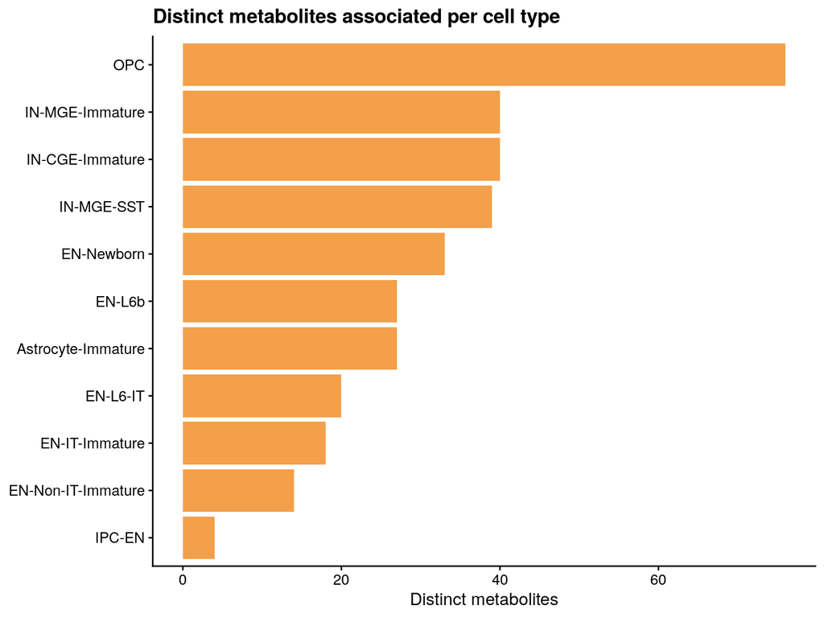

```r
print(p_ct_metab)
```

## Distinct genes by cell type

```r
p_ct_genes <- ggplot(ct_recur,
                     aes(x = reorder(cell_type, n_genes), y = n_genes)) +
  geom_col(fill = "#59A14F", alpha = 0.85) +
  coord_flip() +
  labs(x = NULL, y = "Distinct genes",
       title = "Distinct genes associated per cell type") +
  theme_cowplot(12)

save_dual_format(p_ct_genes, out_dir, "distinct_genes_by_celltype", width = 8, height = 6)
```

```
## Saved: distinct_genes_by_celltype.png  +  svg/distinct_genes_by_celltype.svg
```

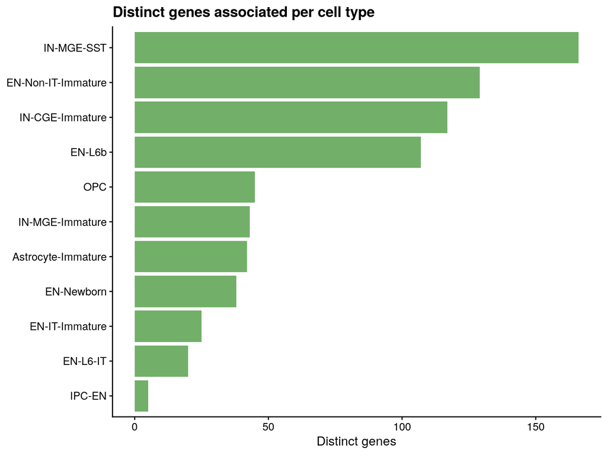

```r
print(p_ct_genes)
```

## Spotlight scatter — helper function

Simple 1-panel scatter showing the covariate-adjusted partial residual (the actual model relationship: gene ~ metabolite after adjusting for GW + Sex + batch1_frac). Points colored by GW, shaped by Sex. One pooled regression line matching model structure.

```r
make_spotlight_scatter <- function(cid, gene, ct, meta_name,
                                   label = NULL) {
  idx      <- which(row_ct == ct)
  pos      <- match(metab_col[idx], colnames(metab_tx))
  present  <- !is.na(pos) & gene %in% colnames(pb$counts)
  rows_use <- idx[present]; pos_p <- pos[present]
  if (length(rows_use) < 3) { message("Too few samples for ", gene, " ~ ", meta_name); return(NULL) }

  # Gene expression: log1p(CPM) computed per cell type
  expr <- as.numeric(log1p(
    edgeR::cpm(t(pb$counts[rows_use, , drop = FALSE]), log = FALSE)[gene, ]
  ))
  md <- pb$metadata[rn[rows_use], ]

  df <- tibble(
    metab = as.numeric(metab_tx[cid, pos_p]),
    expr  = expr,
    Sex   = md$Sex,
    GW    = md$GW,
    batch1_frac = md$batch1_frac
  ) |> filter(!is.na(metab))

  if (nrow(df) < 4) { message("Too few non-NA for ", gene, " ~ ", meta_name); return(NULL) }

  # Partial residual: remove covariate effects, keep metabolite slope
  covs   <- c("GW", "Sex", "batch1_frac")
  keepc  <- covs[vapply(covs, function(cv) length(unique(df[[cv]])) >= 2, logical(1))]
  fit    <- lm(reformulate(c("metab", keepc), response = "expr"), data = df)
  df$partial <- resid(fit) + coef(fit)[["metab"]] * df$metab

  # Stats annotation
  hit_row <- hits |> filter(Compound.ID == cid, gene == !!gene, cell_type == ct)
  lfc_txt <- if (nrow(hit_row) > 0) sprintf("logFC = %.2f", hit_row$logFC[1]) else ""
  fdr_txt <- if (nrow(hit_row) > 0) sprintf("FDR = %.3f",   hit_row$FDR_global[1]) else ""
  stat_label <- paste(lfc_txt, fdr_txt, sep = "  |  ")

  if (is.null(label)) label <- paste0(gene, " ~ ", meta_name, "  (", ct, ")")

  p <- ggplot(df, aes(metab, partial, color = GW)) +
    geom_point(aes(shape = Sex), size = 3, alpha = 0.85) +
    geom_smooth(method = "lm", formula = y ~ x, se = TRUE, linewidth = 0.9,
                color = "grey30") +
    scale_color_viridis_c(name = "GW") +
    scale_shape_manual(values = c("M" = 16, "F" = 17)) +
    annotate("text", x = Inf, y = -Inf, hjust = 1.05, vjust = -0.5,
             label = stat_label, size = 3.5, color = "grey40") +
    labs(x = paste0(meta_name, " [", METHOD, " transformed]"),
         y = "Gene expression [log1p(CPM), adjusted]",
         title = label) +
    theme_cowplot(13)

  p
}
```

## OPC lipid spotlight

OPC has the most distinct metabolites (n = 76), with lipids representing the largest metabolite class. Spotlight pairs connect myelination-associated genes to lipid metabolites.

```r
opc_spotlight_dir <- file.path(csv_dir, "spotlight-opc")
dir.create(opc_spotlight_dir, recursive = TRUE, showWarnings = FALSE)

# ---- BCAS1 ~ Pc(19:5cooh_25:8): myelination marker + phospholipid ----
p_bcas1 <- make_spotlight_scatter(
  cid  = hits |> filter(gene == "BCAS1", cell_type == "OPC",
                         grepl("Glycerophospholipid", Class)) |> pull(Compound.ID) |> first(),
  gene = "BCAS1", ct = "OPC",
  meta_name = hits |> filter(gene == "BCAS1", cell_type == "OPC",
                              grepl("Glycerophospholipid", Class)) |> pull(Name) |> first()
)
if (!is.null(p_bcas1)) {
  save_dual_format(p_bcas1, opc_spotlight_dir, "OPC_BCAS1_phospholipid", width = 8, height = 6)
  print(p_bcas1)
}
```

```
## Saved: OPC_BCAS1_phospholipid.png  +  svg/OPC_BCAS1_phospholipid.svg
```

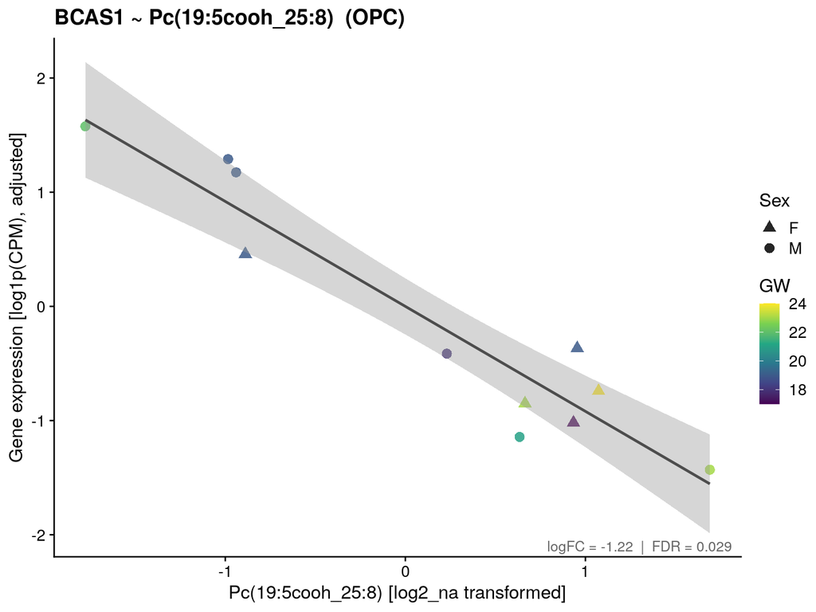

```r
# ---- PLCG2 ~ Palmitic Acid: phospholipase + fatty acid substrate ----
p_plcg2 <- make_spotlight_scatter(
  cid  = hits |> filter(gene == "PLCG2", Name == "Palmitic Acid", cell_type == "OPC") |>
           pull(Compound.ID) |> first(),
  gene = "PLCG2", ct = "OPC",
  meta_name = "Palmitic Acid"
)
if (!is.null(p_plcg2)) {
  save_dual_format(p_plcg2, opc_spotlight_dir, "OPC_PLCG2_palmitic", width = 8, height = 6)
  print(p_plcg2)
}
```

```
## Saved: OPC_PLCG2_palmitic.png  +  svg/OPC_PLCG2_palmitic.svg
```

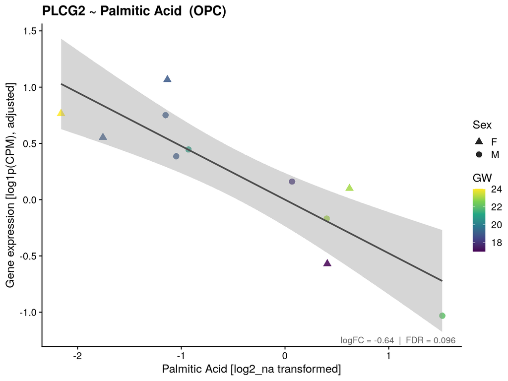

```r
# ---- NRG1 ~ Pc(O-10:0_23:2): OPC differentiation signal + phospholipid ----
p_nrg1 <- make_spotlight_scatter(
  cid  = hits |> filter(gene == "NRG1", cell_type == "OPC") |> pull(Compound.ID) |> first(),
  gene = "NRG1", ct = "OPC",
  meta_name = hits |> filter(gene == "NRG1", cell_type == "OPC") |> pull(Name) |> first()
)
if (!is.null(p_nrg1)) {
  save_dual_format(p_nrg1, opc_spotlight_dir, "OPC_NRG1_phospholipid", width = 8, height = 6)
  print(p_nrg1)
}
```

```
## Saved: OPC_NRG1_phospholipid.png  +  svg/OPC_NRG1_phospholipid.svg
```

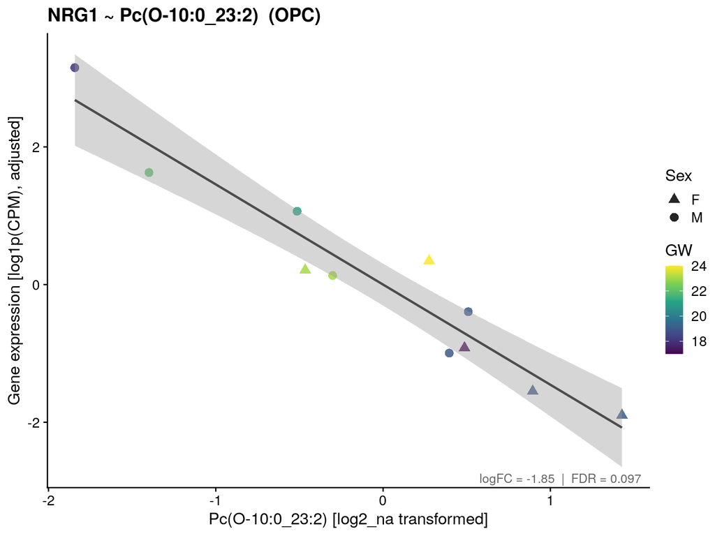

## Interpretation spotlight scatters

```r
interp_dir <- file.path(csv_dir, "spotlight-interpretation")
dir.create(interp_dir, recursive = TRUE, showWarnings = FALSE)

# ---- 1. Direct: PLCG2 ~ Cer(D15:2_7:0) in OPC ----
# Phospholipase C gamma 2 cleaves lipid substrates; ceramide association is a direct enzyme-substrate class relationship.
p_direct <- make_spotlight_scatter(
  cid  = hits |> filter(gene == "PLCG2", cell_type == "OPC",
                         grepl("Cer", Name)) |> pull(Compound.ID) |> first(),
  gene = "PLCG2", ct = "OPC",
  meta_name = hits |> filter(gene == "PLCG2", cell_type == "OPC",
                              grepl("Cer", Name)) |> pull(Name) |> first(),
  label    = "Direct: PLCG2 ~ ceramide (OPC)"
)
if (!is.null(p_direct)) {
  save_dual_format(p_direct, interp_dir, "direct_PLCG2_ceramide", width = 8, height = 6)
  print(p_direct)
}
```

```
## Saved: direct_PLCG2_ceramide.png  +  svg/direct_PLCG2_ceramide.svg
```

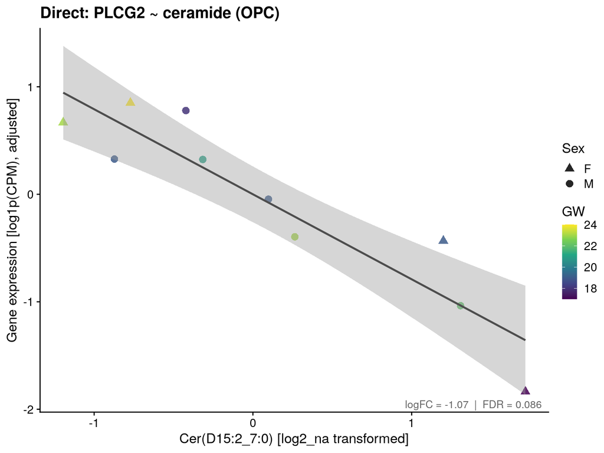

```r
# ---- 2. Ribosomal: RPL37A ~ Pyrrole-2-Carboxylic Acid in EN-Non-IT-Immature ----
# RPL37A has the most metabolite associations among ribosomal genes (5).
# 73 RPL/RPS genes collectively associate with Pyrrole-2-Carboxylic Acid
p_ribo <- make_spotlight_scatter(
  cid  = hits |> filter(gene == "RPL37A",
                         Name == "Pyrrole-2-Carboxylic Acid") |>
           pull(Compound.ID) |> first(),
  gene = "RPL37A", ct = "EN-Non-IT-Immature",
  meta_name = "Pyrrole-2-Carboxylic Acid",
  label    = "Ribosomal: RPL37A ~ Pyrrole-2-Carboxylic Acid (EN-Non-IT-Immature)"
)
if (!is.null(p_ribo)) {
  save_dual_format(p_ribo, interp_dir, "ribosomal_RPL37A_pyrrole", width = 8, height = 6)
  print(p_ribo)
}
```

```
## Saved: ribosomal_RPL37A_pyrrole.png  +  svg/ribosomal_RPL37A_pyrrole.svg
```

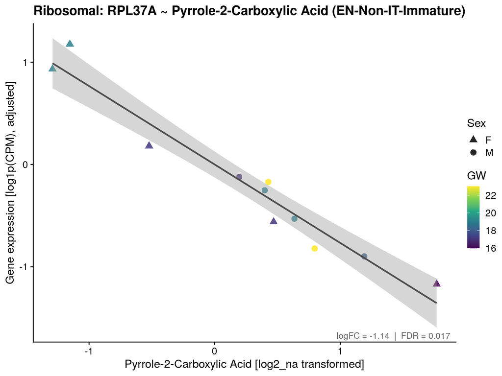

```r
# ---- 3. Indirect: TSHZ2 ~ Palmitic Acid in IN-MGE-SST ----
# TSHZ2 is a zinc-finger TF for cortical neuron specification
# No enzymatic link to fatty acid metabolism
p_tf <- make_spotlight_scatter(
  cid  = hits |> filter(gene == "TSHZ2", Name == "Palmitic Acid",
                         cell_type == "IN-MGE-SST") |>
           pull(Compound.ID) |> first(),
  gene = "TSHZ2", ct = "IN-MGE-SST",
  meta_name = "Palmitic Acid",
  label    = "Indirect: TSHZ2 ~ Palmitic Acid (IN-MGE-SST)"
)
if (!is.null(p_tf)) {
  save_dual_format(p_tf, interp_dir, "indirect_TSHZ2_palmitic", width = 8, height = 6)
  print(p_tf)
}
```

```
## Saved: indirect_TSHZ2_palmitic.png  +  svg/indirect_TSHZ2_palmitic.svg
```

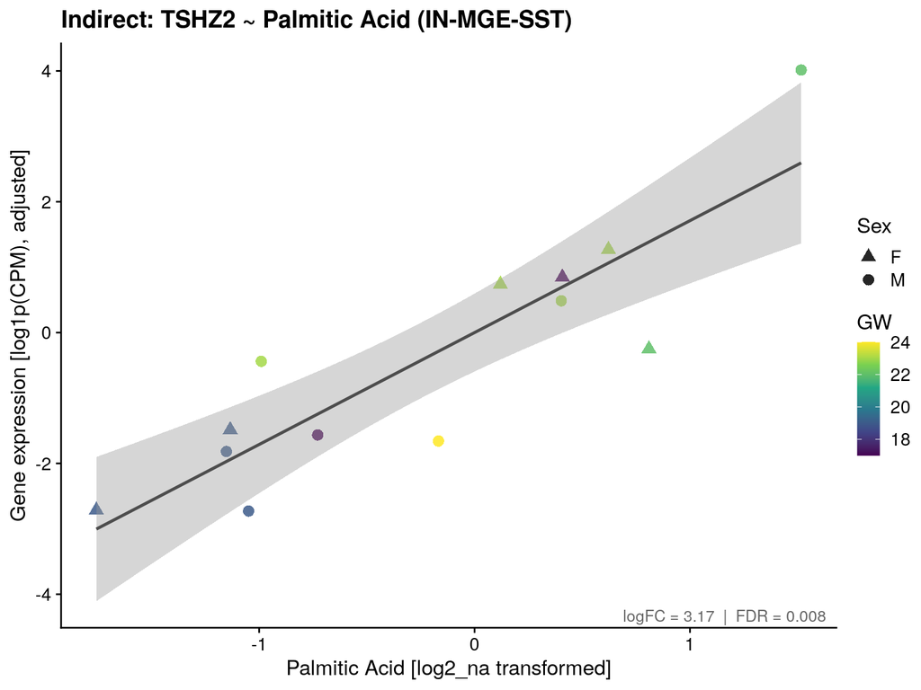

## IN-MGE-SST top 10 associations

IN-MGE-SST has the highest total association count. Spotlight scatters for the 10 strongest associations (ranked by global FDR, then |logFC|).

```r
sst_dir <- file.path(csv_dir, "spotlight-IN-MGE-SST")
dir.create(sst_dir, recursive = TRUE, showWarnings = FALSE)

sst_top10 <- hits |>
  filter(cell_type == "IN-MGE-SST") |>
  arrange(FDR_global, desc(abs(logFC))) |>
  slice_head(n = 10)

for (i in seq_len(nrow(sst_top10))) {
  r  <- sst_top10[i, ]
  pl <- make_spotlight_scatter(
    cid       = r$Compound.ID,
    gene      = r$gene,
    ct        = "IN-MGE-SST",
    meta_name = r$Name
  )
  if (is.null(pl)) next
  base <- gsub("[^A-Za-z0-9]+", "-", paste("SST", r$gene, r$Name, sep = "_"))
  save_dual_format(pl, sst_dir, base, width = 8, height = 6)
  print(pl)
}
```

```
## Saved: SST-TSHZ2-2-1s-4s-6s-4-5-4-Dimethylamino-Phenyl-1-3-4-Oxadiazol-2-Yl-Methyl-6-Isopropyl-3-Methyl-2-Cyclohexen-1-Yl-Methyl-Methyl-Amino-Ethanol.png  +  svg/SST-TSHZ2-2-1s-4s-6s-4-5-4-Dimethylamino-Phenyl-1-3-4-Oxadiazol-2-Yl-Methyl-6-Isopropyl-3-Methyl-2-Cyclohexen-1-Yl-Methyl-Methyl-Amino-…
```

```
## Saved: SST-PLCG2-Pyruvic-Acid.png  +  svg/SST-PLCG2-Pyruvic-Acid.svg
```

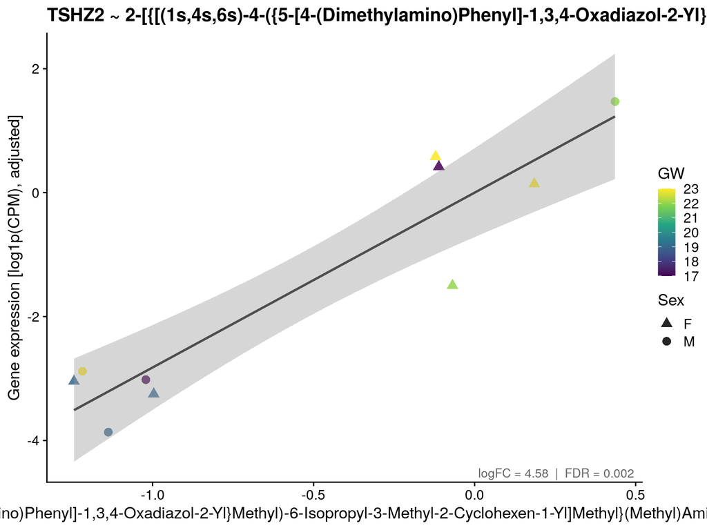

```
## Saved: SST-ENSG00000271774-Palmitic-Acid.png  +  svg/SST-ENSG00000271774-Palmitic-Acid.svg
```

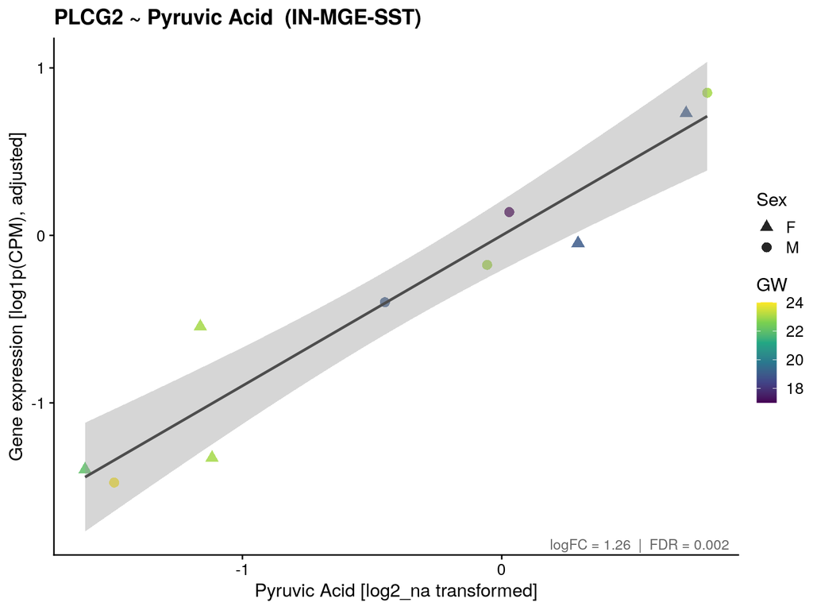

```
## Saved: SST-TSHZ2-Dl-Arginine.png  +  svg/SST-TSHZ2-Dl-Arginine.svg
```

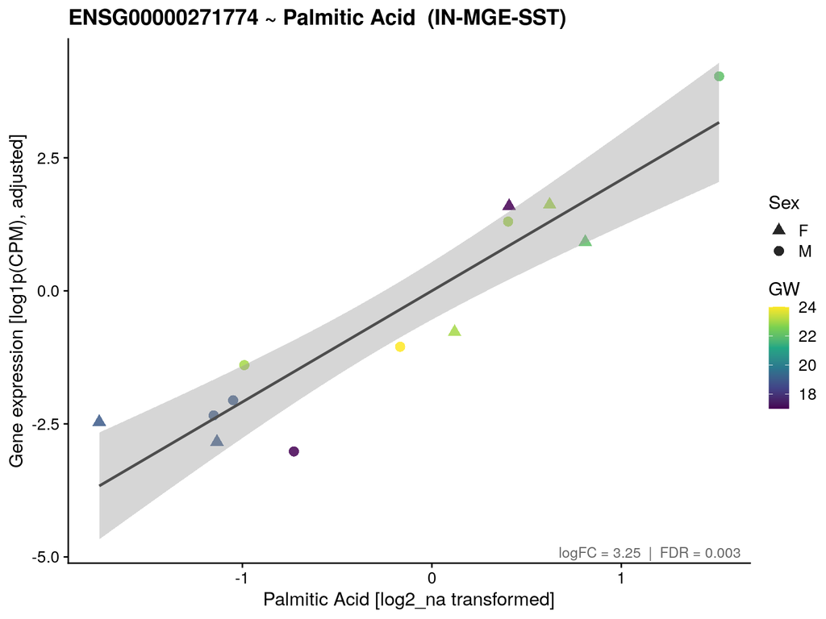

```
## Saved: SST-EBF1-S-4-2-Oxo-Butyl-Glutathione.png  +  svg/SST-EBF1-S-4-2-Oxo-Butyl-Glutathione.svg
```

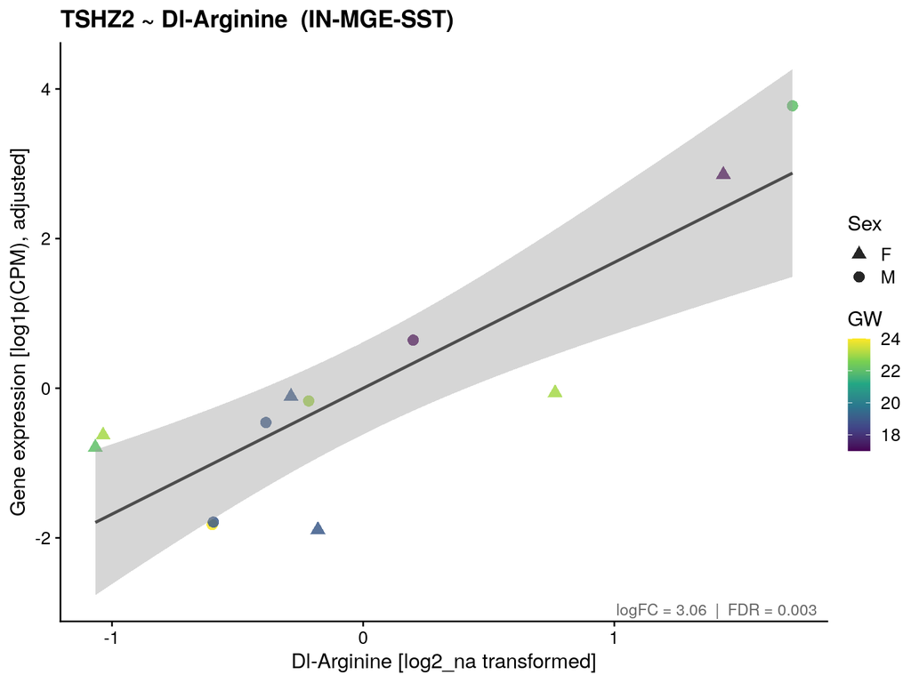

```
## Saved: SST-RPS19-Pyruvic-Acid.png  +  svg/SST-RPS19-Pyruvic-Acid.svg
```

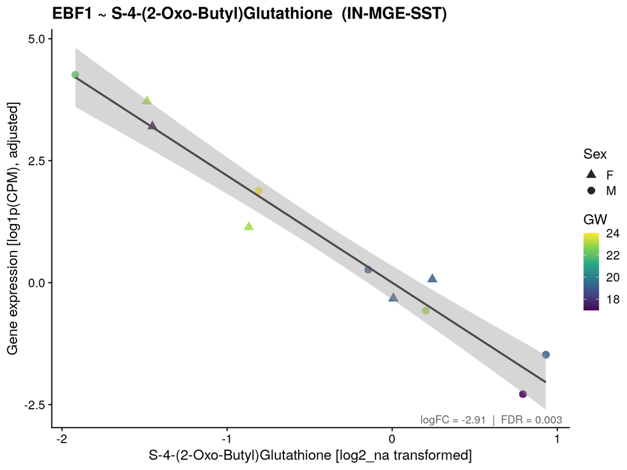

```
## Saved: SST-RPS29-Pyruvic-Acid.png  +  svg/SST-RPS29-Pyruvic-Acid.svg
```

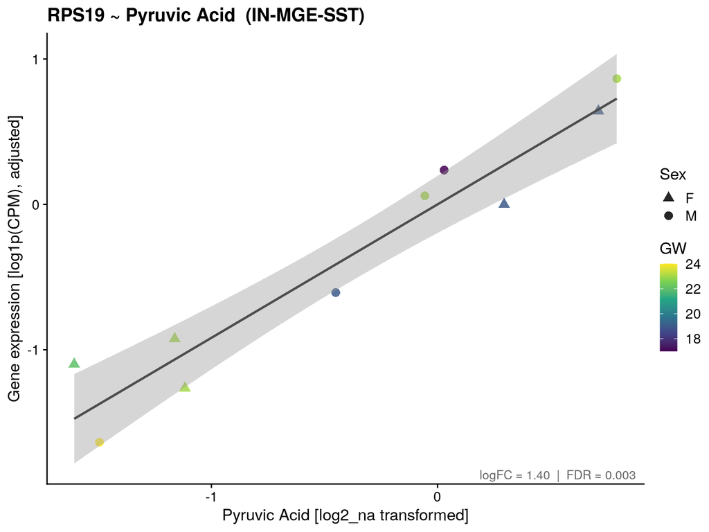

```
## Saved: SST-RPL37A-Pyruvic-Acid.png  +  svg/SST-RPL37A-Pyruvic-Acid.svg
```

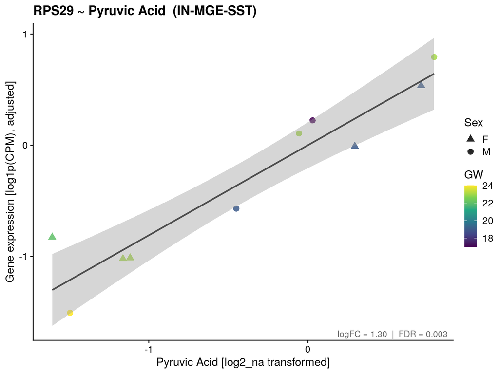

```
## Saved: SST-RPL10-Pyruvic-Acid.png  +  svg/SST-RPL10-Pyruvic-Acid.svg
```

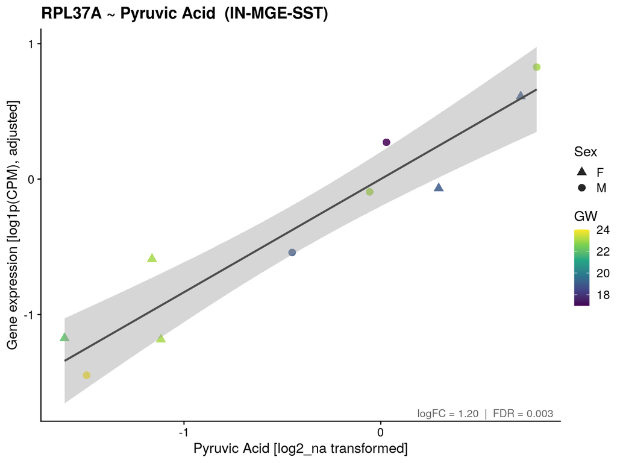

```
## Saved: SST-ENSG00000271774-L-Hydroxyproline.png  +  svg/SST-ENSG00000271774-L-Hydroxyproline.svg
```

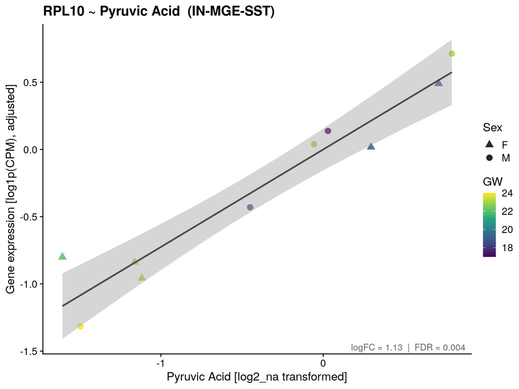

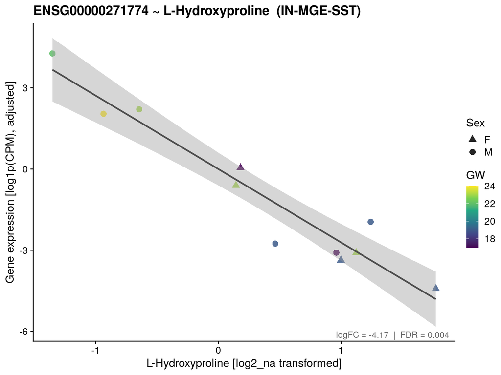

```r
cat("Saved", nrow(sst_top10), "IN-MGE-SST spotlight scatters to", sst_dir, "\n")
```

```
## Saved 10 IN-MGE-SST spotlight scatters to /scratch/jdlab/sneha/developing-brain-metabolomics/results/gene-metabolite/csv-log2_na/spotlight-IN-MGE-SST
```

# AI Assistance Disclosure

Code in this script was developed with assistance from Claude (Anthropic). All AI-generated code was reviewed, validated, and adapted by the author.